[figure not shown]

Лабораторная работа №9

Использование протокола STP. Агрегирование каналов

Сахно Никита Вячеславович

Российский университет дружбы народов, Москва, Россия

1/25

[figure not shown]

Цель работы

Изучить возможности протокола STP и его модификаций по обеспечению

отказоустойчивости сети, агрегированию интерфейсов и перераспределению нагрузки

между ними.

[figure not shown]

Задание

1. Сформировать резервное соединение между коммутаторами msk-donskayasw-1 и

msk-donskaya-sw-3.

2. Настроить балансировку нагрузки между резервными соединениями.

3. Настроить режим Portfast на тех интерфейсах коммутаторов, к которым подключены

серверы.

4. Изучить отказоустойчивость резервного соединения.

5. Сформировать и настроить агрегированное соединение интерфейсов Fa0/20 –Fa0/23

между коммутаторами msk-donskaya-sw-1 иmsk-donskaya-sw-4.

6. При выполнении работы необходимо учитывать соглашение об именовании.

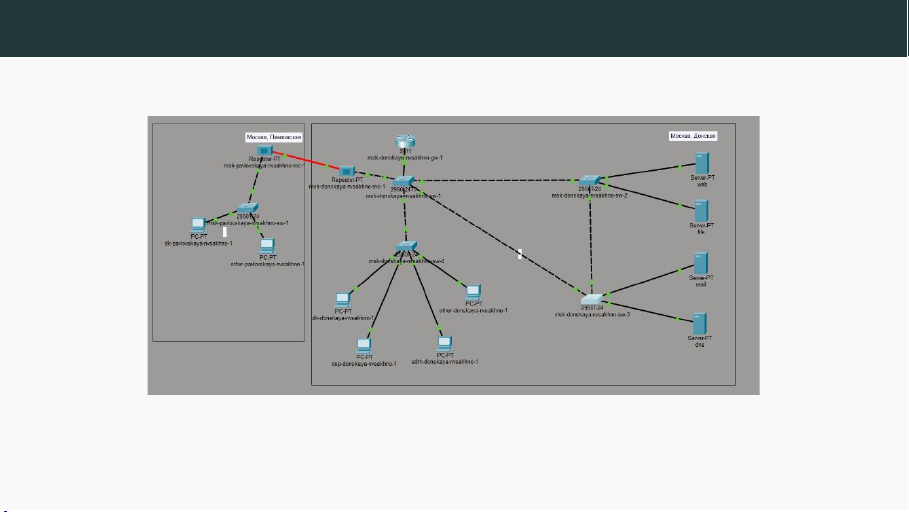

Выполнение лабораторной работы

Рис. 1: Логическая схема локальной сети с резервным соединением

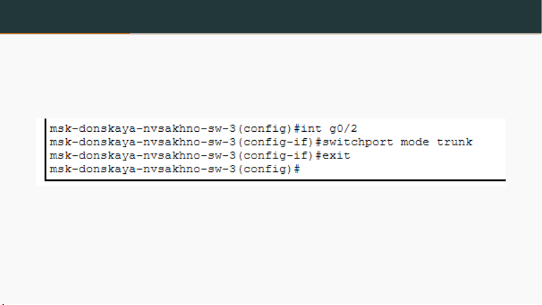

Выполнение лабораторной работы

Рис. 2: Настройка trunk-порта на интерфейсе Gig0/2 коммутатора msk-donskaya-sw-3

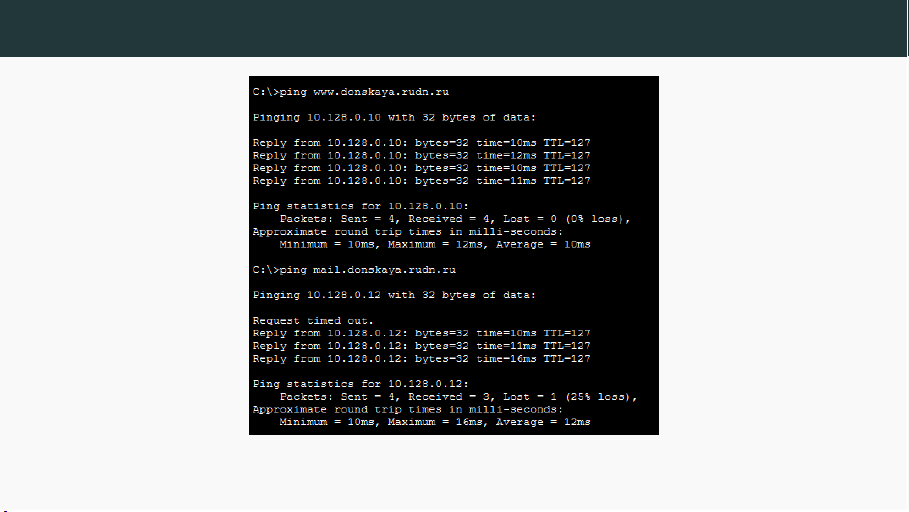

Выполнение лабораторной работы

Рис. 3: Пингование сервера mail иweb 7/25

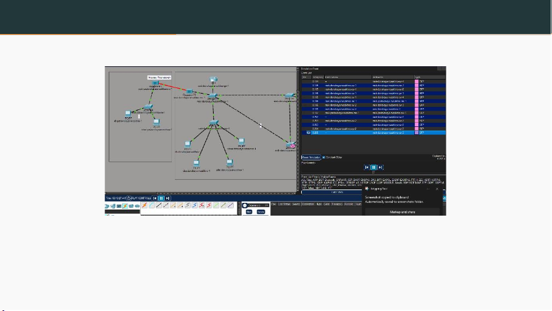

Выполнение лабораторной работы

Рис. 4: Режим симуляции движения пакетов ICMP

8/25

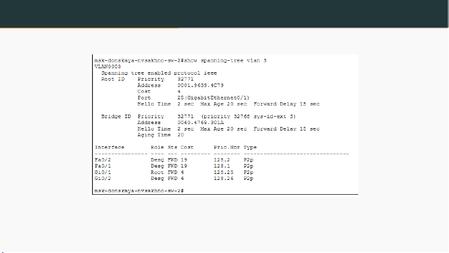

Выполнение лабораторной работы

Рис. 6: Просмотр состояния протокола STP для vlan 3

10/25

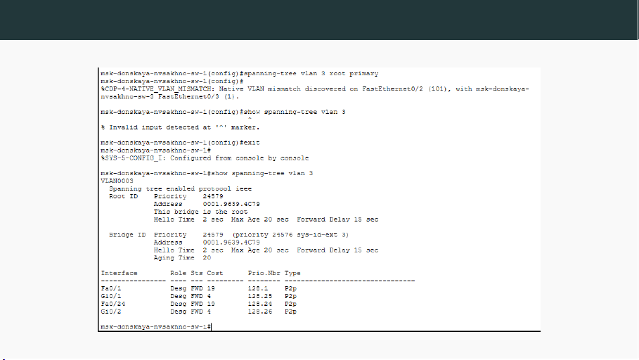

Выполнение лабораторной работы

Рис. 7: Настройка коммутатора msk-donskaya-sw-1корневым

11/25

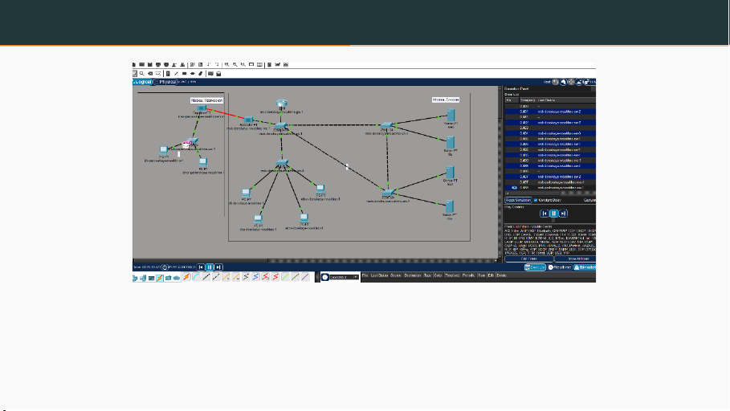

Выполнение лабораторной работы

Рис. 8: Режим симуляции движения пакетов ICMP к серверу web

12/25

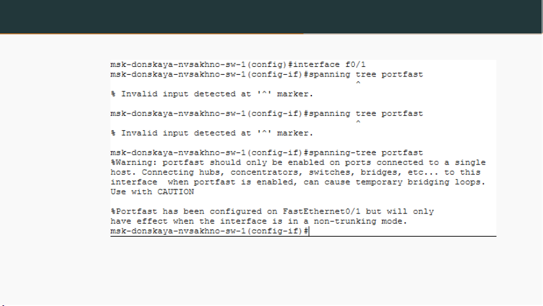

Выполнение лабораторной работы

Рис. 10: Настройка режима Portfast

14/25

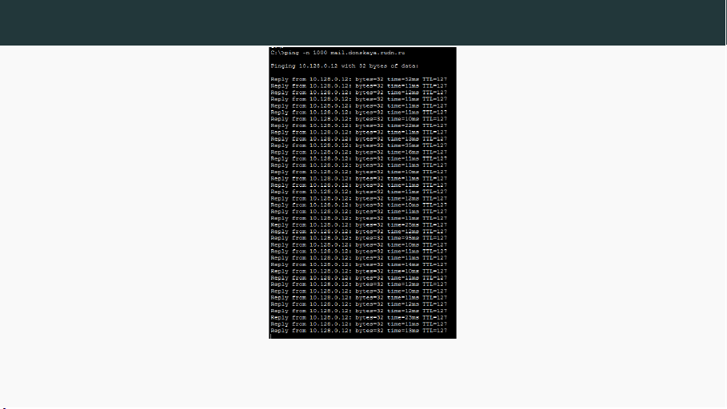

Выполнение лабораторной работы

Рис. 11: Пингование mail.donskaya.rudn.ru

15/25

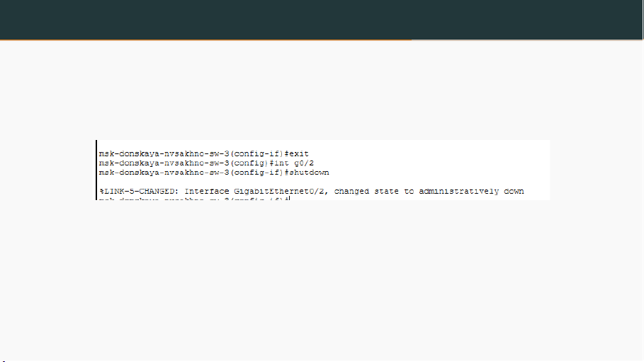

Выполнение лабораторной работы

Рис. 12: Разрыв соединения

16/25

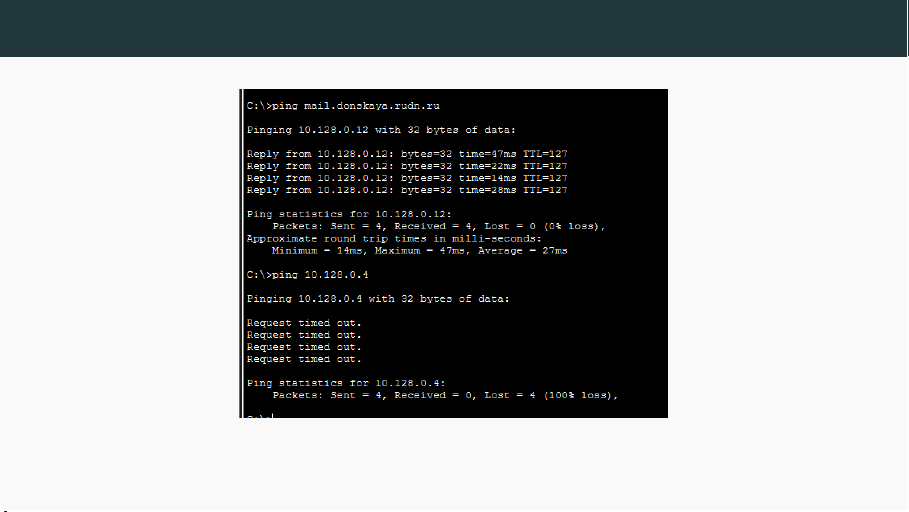

Выполнение лабораторной работы

Рис. 13: Время восстановления соединения

17/25

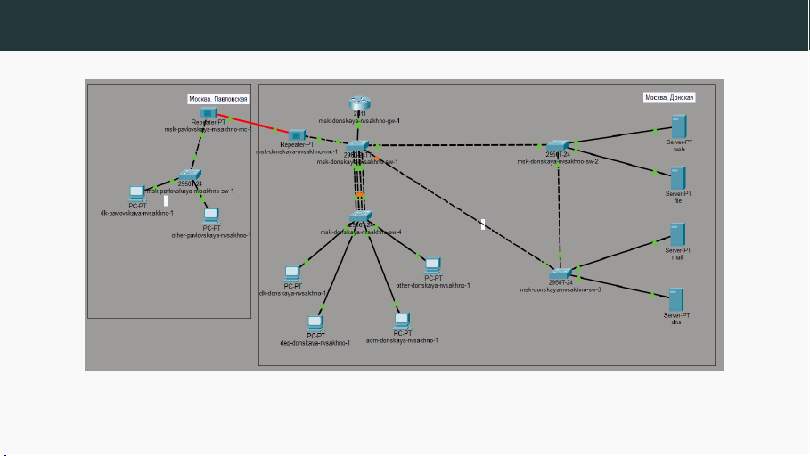

Выполнение лабораторной работы

Рис. 18: Логическая схема локальной сети с агрегированным соединением

22/25

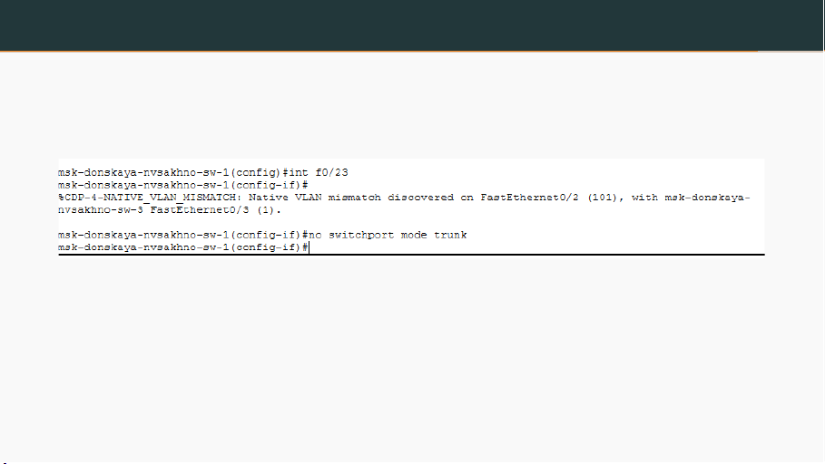

Выполнение лабораторной работы

Рис. 19: Настройка агрегирования каналов на msk-donskaya-nvsakhno-sw-1

23/25

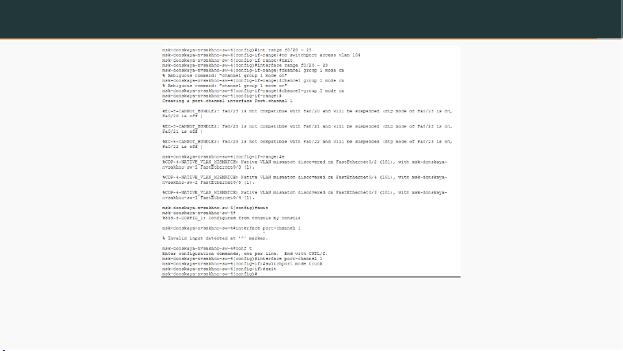

Выполнение лабораторной работы

24/25

[figure not shown]

Выводы

В результате выполнения лабораторной работы я изучил возможности протокола STP и

его модификаций по обеспечению отказоустойчивости сети, агрегированию интерфейсов

и перераспределению нагрузки между ними.

25/25